# Project 2 - International Migrant Stock (1 of 3)

Jai Jeffryes

10/4/2019

```r
knitr::opts_chunk$set(echo = TRUE)
library(knitr)
library(openxlsx)
library(tidyr)
library(dplyr)
library(ggplot2)
```

- Introduction
- Read
- Clean
  - Validate filters
- Exploratory Data Analysis
  - Compare proportions by sex
  - Compare proportions by sex over major region
  - Compare distributions
  - View proportions by country

## Introduction

Project 2 required data tidying for three data sets. I chose data sets about:

1. International migrant stock reported by the U.N.
2. A chess tournament reported by the Continental Chess Association.
3. Per capita expenditures by counties of Maryland in 2010.

Finding appropriate datasets from the discussion board was challenging due to misunderstanding of the goals of so-called tidying, a structural reorganization distinct from other aspects of data cleansing. Many described their contributions using the imprecise term, “messy,” and though the data quality may have justified some form of cleansing transformations, the contributions were commonly already tidy, namely having a single variable per column and a single observation per row.

Cross tab reports are common and they lend themselves well to reorganization by tidy principles. This analysis examines data reported by the United Nations.

International migrant stock is the number of people born in a country other than the one where they live. The United Nations Department of Economic and Social Affairs, Population Division publishes estimates of international migrants by age, sex, and origin. Data for international migrant stock as of 2019 are available [here](https://www.un.org/en/development/desa/population/migration/data/estimates2/estimates19.asp).

I downloaded the 2019 dataset manually.

- Link: [Total international migrant stock](https://www.un.org/en/development/desa/population/migration/data/estimates2/data/UN_MigrantStockTotal_2019.xlsx)
- Date: 9/24/2019
- Citation: United Nations, Department of Economic and Social Affairs. Population Division (2019). International Migrant Stock 2019 (United Nations database, POP/DB/MIG/Stock/Rev.2019).

I reorganized the data for analysis, and explored gender statistics.

## Read

The data format is Excel. I used the package `openxlsx`, available on [CRAN](https://cran.r-project.org/web/packages/openxlsx/index.html). `openxlsx` is a reliable alternative to other Excel interfaces that rely on Java.

The workbook contains multiple worksheets:

- Table of contents.
- Tables 1-6.
- Annex. Cross reference for categorical variables, such as “More Developed Regions”, “High Income Countries,” etc.
- Notes. Footnotes for data annotations in the tables.

This analysis examines **Table 1 - International migrant stock at mid-year by sex and by major area, region, country or area, 1990-2019**.

```r
rows <- c(16, 38:240, 242:299)
cols <- c(2, 13:26)
migrant_raw <- readWorkbook(xlsxFile = "./data/UN_MigrantStockTotal_2019.xlsx",
                            sheet = 2,
                            rows = rows,
                            cols = cols,
                            na.strings = "..")
```

## Clean

- Row filtering is coded in the `rows` vector used by `readWorkbook()`.
  - The headings we are interested in are values for a `year` variable. They appear in row 16.
  - The worksheet contains summary rows at the top which I ignore in this analysis as I compute summaries. I import detail by country. The body of the report contains summarizations at multiple levels of aggregation. I summarize at two levels of aggregation for geographic location, major area and region. The detail grain of the report is country. In the initial read, I retain summary rows for major area and region in order to use the descriptions for populating categorical variable, after which I discard the summary rows.
- Column filtering is coded in the `cols` vector used by `readWorkbook()`. I retain the geographic location and the yearly measures for each sex. I ignore sort order, notes, codes, type of data, and the yearly total measures for both sexes.
- NA values are coded in the file as “..”.

```r
# Split sexes.
migrant_clean_m <- tbl_df(migrant_raw[ , 1:8])
migrant_clean_f <- tbl_df(migrant_raw[ , c(1, 9:15)])

# Create dimension variables.
migrant_clean_m <- cbind(major_area = NA,
                         region = NA,
                         country = migrant_clean_m$X1,
                         sex = "male",
                         migrant_clean_m[ , 2:8],
                         stringsAsFactors = FALSE)
migrant_clean_f <- cbind(major_area = NA,
                         region = NA,
                         country = migrant_clean_f$X1,
                         sex = "female",
                         migrant_clean_f[ , 2:8],
                         stringsAsFactors = FALSE)

# Populate dimensions on breaks.
major_area_idx <- c(1, 57, 85, 102, 123, 175, 203)
region_idx <- c(2, 23, 33, 39, 58, 66, 86, 92, 103, 111, 124, 151, 160, 176, 179, 185, 193, 204, 215, 229, 246, 256)
migrant_clean_m$major_area[major_area_idx] <- migrant_clean_m$country[major_area_idx]
migrant_clean_m$region[region_idx] <- migrant_clean_m$country[region_idx]
migrant_clean_f$major_area[major_area_idx] <- migrant_clean_f$country[major_area_idx]
migrant_clean_f$region[region_idx] <- migrant_clean_f$country[region_idx]

# Fill dimensions
migrant_clean_m <- migrant_clean_m %>% fill(1:2, .direction = c("down"))
migrant_clean_f <- migrant_clean_f %>% fill(1:2, .direction = c("down"))

# Discard summary rows.
migrant_clean_m <- migrant_clean_m[-c(major_area_idx, region_idx), ]
migrant_clean_f <- migrant_clean_f[-c(major_area_idx, region_idx), ]

# Pivot year variable.
migrant_clean_m <- migrant_clean_m %>% gather(year, count, 5:length(migrant_clean_m))
migrant_clean_f <- migrant_clean_f %>% gather(year, count, 5:length(migrant_clean_f))

# Merge partitions.
migrant_clean <- tbl_df(rbind(migrant_clean_m, migrant_clean_f)) %>% arrange(major_area, region, country, year, sex)

# Create factors.
migrant_clean$major_area <- factor(migrant_clean$major_area)
migrant_clean$region <- factor(migrant_clean$region)
migrant_clean$country <- factor(migrant_clean$country)
migrant_clean$sex <- factor(migrant_clean$sex)

# Data types.
migrant_clean$year <- as.integer(migrant_clean$year)
```

### Validate filters

The report presents totals for both sexes. My organization of the data removes summary rows. I validated that I removed the necessary rows and no more than that. I compared the world totals by year from my cleaned data set against the world totals in the report and found no differences.

```r
tot_world_clean <- migrant_clean %>%
    filter(!is.na(count)) %>%
    group_by(year) %>%
    summarize(total = sum(count)) %>%
    rename(tot_clean = total)

tot_raw <- readWorkbook(xlsxFile = "./data/UN_MigrantStockTotal_2019.xlsx",
                            sheet = 2,
                            rows = 16:17,
                            cols = 6:12,
                            na.strings = "..")
tot_raw <- tbl_df(t(tot_raw)) %>%
    rename(tot_raw = 1)

tot_compare <- cbind(tot_world_clean, tot_raw) %>%
    mutate(difference = tot_clean - tot_raw)

kable(tot_compare, caption = "Validation of World Totals")
```

Validation of World Totals

| year | tot_clean | tot_raw | difference |
| --- | --- | --- | --- |
| 1990 | 153011473 | 153011473 | 0 |
| 1995 | 161316895 | 161316895 | 0 |
| 2000 | 173588441 | 173588441 | 0 |
| 2005 | 191615574 | 191615574 | 0 |
| 2010 | 220781909 | 220781909 | 0 |
| 2015 | 248861296 | 248861296 | 0 |
| 2019 | 271642105 | 271642105 | 0 |

## Exploratory data analysis

### Compare proportions by sex

The proportion of male migrants is higher than that of females in each year.

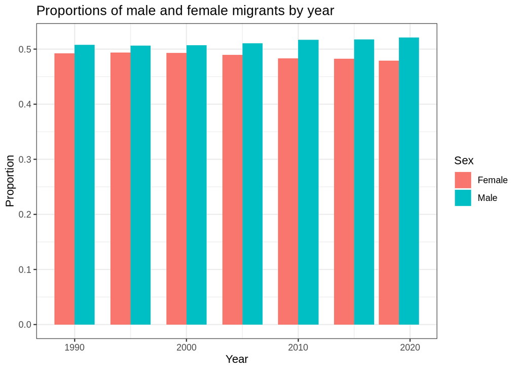

```r
sex_prop_year <- migrant_clean %>%
    filter(!is.na(count)) %>%
    group_by(sex, year) %>%
    summarize(count = sum(count)) %>%
    spread(sex, count) %>%                     # Pivot the summaries for computed columns
    mutate(total = .[[2]] + .[[3]],            # Create computed columns for proportions
           Male = male / total,
           Female = female / total) %>%
    gather(Sex, Proportion, Male:Female)       # Unpivot the results again for plotting
sex_prop_year$Sex <- factor(sex_prop_year$Sex) # Aesthetic mappings needs factors

ggplot(data = sex_prop_year) +
    geom_col(aes(x = year, y = Proportion, fill = Sex), position = "dodge") +
    labs(title = "Proportions of male and female migrants by year",
         x = "Year",
         y = "Proportion") +
    theme_bw()
```

The proportion of male migrants is rising.

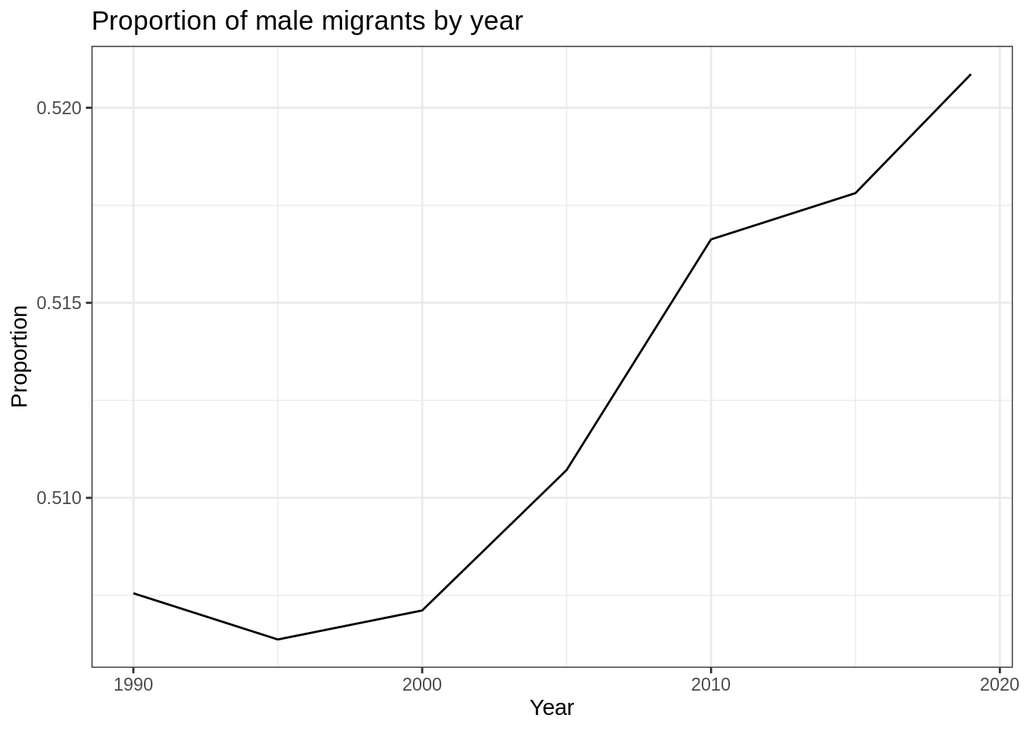

```r
ggplot(data = subset(sex_prop_year, Sex == "Male")) +
    geom_line(mapping = aes(x = year, y = Proportion), stat = "identity") +
    labs(title = "Proportion of male migrants by year",
         x = "Year",
         y = "Proportion") +
    theme_bw()
```

### Compare proportions by sex over major region

We can view these proportions by major region over all time.

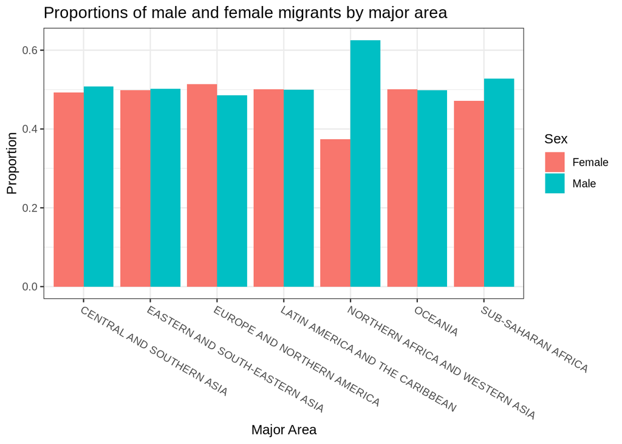

```r
sex_prop_major_area <- migrant_clean %>%
    filter(!is.na(count)) %>%
    group_by(sex, major_area) %>%
    summarize(count = sum(count)) %>%
    spread(sex, count) %>%                                    # Pivot the summaries for computed columns
    mutate(Total = female + male,                             # Create computed columns for proportions
           Male = male / Total,
           Female = female / Total) %>%
    gather(Sex, Proportion, Male:Female)                      # Unpivot the results again for plotting
sex_prop_major_area$Sex <- factor(sex_prop_major_area$Sex) # Aesthetic mappings needs factors

ggplot(data = sex_prop_major_area) +
    geom_col(aes(x = major_area, y = Proportion, fill = Sex), position = "dodge") +
    labs(title = "Proportions of male and female migrants by major area",
         x = "Major Area",
         y = "Proportion") +
    theme_bw() + # Use built in theme
    # Then customize theme
    theme(axis.text.x = element_text(angle = -30, hjust = 0)) # Justification 0 = left, 1 = right
```

The major area where the proportion of male migrants is highest is Northern Africa and Western Asia. We can examine the trend over time. The proportion began a marked increase following the year 2000. It plateaued in 2010 and has remained high since then.

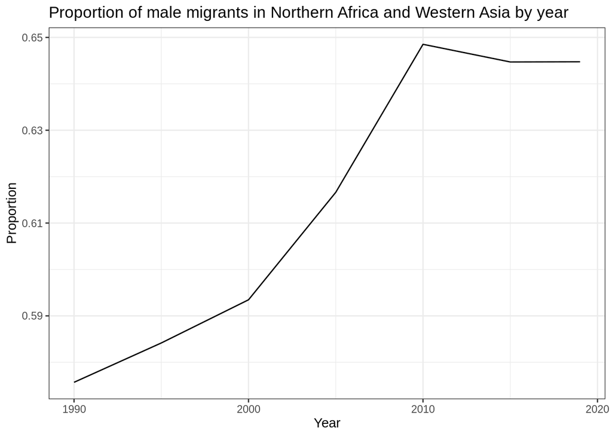

```r
sex_prop_nafrica_wasia_year <- migrant_clean %>%
    filter(!is.na(count),
           major_area == "NORTHERN AFRICA AND WESTERN ASIA") %>%
    group_by(sex, year) %>%
    summarize(count = sum(count)) %>%
    spread(sex, count) %>%                     # Pivot the summaries for computed columns
    mutate(total = female + male,              # Create computed columns for proportions
           Male = male / total,
           Female = female / total) %>%
    gather(Sex, Proportion, Male:Female)       # Unpivot the results again for plotting
sex_prop_year$Sex <- factor(sex_prop_year$Sex) # Aesthetic mappings needs factors

ggplot(data = subset(sex_prop_nafrica_wasia_year, Sex == "Male")) +
    geom_line(mapping = aes(x = year, y = Proportion), stat = "identity") +
    labs(title = "Proportion of male migrants in Northern Africa and Western Asia by year",
         x = "Year",
         y = "Proportion") +
    theme_bw()
```

### Compare distributions

Compare the distributions of proportions of migrant stock by sex over all countries in year 2019.

```r
sex_prop_country <- migrant_clean %>%
    filter(!is.na(count),
           year == 2019) %>%
    group_by(sex, country) %>%
    summarize(count = sum(count)) %>%
    spread(sex, count) %>%                           # Pivot the summaries for computed columns
    mutate(total = female + male,                    # Create computed columns for proportions
           Male = male / total,
           Female = female / total) %>%
    gather(Sex, Proportion, Male:Female)             # Unpivot the results again for plotting
sex_prop_country$Sex <- factor(sex_prop_country$Sex) # Aesthetic mappings needs factors

kable(summary(subset(sex_prop_country, Sex == "Male")["Proportion"]),
      caption = "Summary for Males",
      align = "l")
```

Summary for Males

|  | Proportion |
| --- | --- |
|  | Min. :0.3025 |
|  | 1st Qu.:0.4800 |
|  | Median :0.5066 |
|  | Mean :0.5190 |
|  | 3rd Qu.:0.5402 |
|  | Max. :0.8767 |

```r
kable(summary(subset(sex_prop_country, Sex == "Female")["Proportion"]),
      caption = "Summary for Females",
      align = "l")
```

Summary for Females

|  | Proportion |
| --- | --- |
|  | Min. :0.1233 |
|  | 1st Qu.:0.4598 |
|  | Median :0.4934 |
|  | Mean :0.4810 |
|  | 3rd Qu.:0.5200 |
|  | Max. :0.6975 |

Compare the distributions visually. Naturally, the proportions of the sexes complement each other.

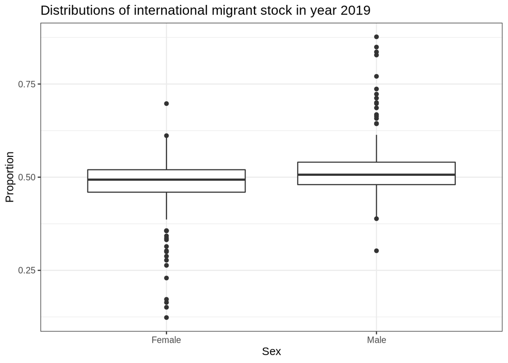

```r
ggplot(sex_prop_country) +
    geom_boxplot(mapping = aes(x = Sex, y = Proportion)) +
    labs(title = "Distributions of international migrant stock in year 2019",
         x = "Sex",
         y = "Proportion") +
    theme_bw()
```

### View proportions by country

We can view countries with the highest proportion of male international migrant stock for the current year, 2019.

```r
df_m <- sex_prop_country %>%
    filter(Sex == "Male") %>%
    arrange(desc(Proportion)) %>%
    top_n(25)
```

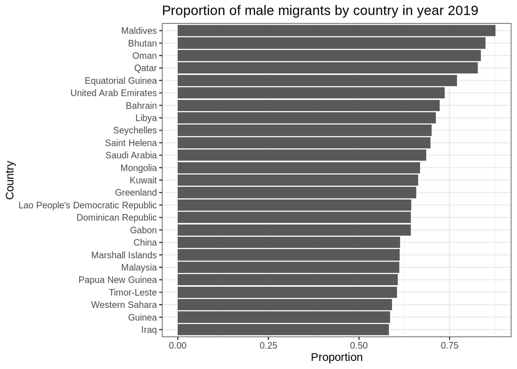

```r
ggplot(data = df_m) +
    geom_col(aes(x = reorder(country, Proportion), y = Proportion)) +
    coord_flip() +
    labs(title = "Proportion of male migrants by country in year 2019",
         x = "Country",
         y = "Proportion") +
    theme_bw()
```

Conversely, we can view countries with the highest proportion of female international migrant stock for the current year, 2019.

```r
df_f <- sex_prop_country %>%
    filter(Sex == "Female") %>%
    arrange(desc(Proportion)) %>%
    top_n(25)
```

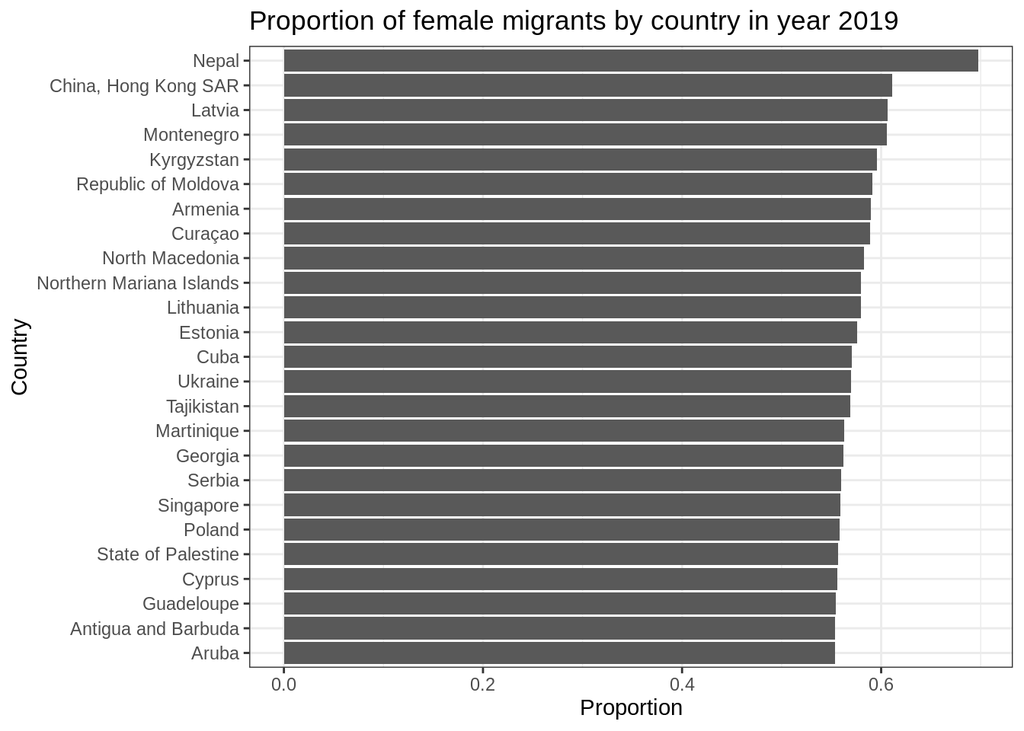

```r
ggplot(data = df_f) +
    geom_col(aes(x = reorder(country, Proportion), y = Proportion)) +
    coord_flip() +
    labs(title = "Proportion of female migrants by country in year 2019",
         x = "Country",
         y = "Proportion") +
    theme_bw()
```